# synthpop_for_rew_connectivity

F. Beyer

7/20/2020

## Synthesizing data for the project on BMI and reward connectivity

In this notebook, I synthesize the data needed to replicate the data structure, and main findings from the publication “Higher BMI, but not obesity-related genetic polymorphisms, correlates with lower structural connectivity of the reward network in a population-based study” by Beyer et al.

The preprint of the paper can be found on biorxiv.

### Loading the real data

First, we load the real data and select the variables relevant for the main analyses of the manuscript. These are age, sex, BMI, FTO and Taq1A-risk (3, 2 levels, respectively), relative number of streamlines (NOS) and fractional anisotropy (FA) connectivity strength (CS) and clustering coefficient (CC).

```r
final_sample=read.csv("/data/p_life_results/2017_beyer_reward_connectivity/DTI/Paper_2019/scripts/final_sample.csv")
final_sample$FTO_risk=as.factor(final_sample$FTO_risk)
final_sample$Taq1A_risk=as.factor(final_sample$Taq1A_risk)

data_for_synth=final_sample[,c("Age_all","sex","BMI_BMI","FTO_risk","Taq1A_risk","rel_FA_strength", "rel_FA_CC","rel_NOS_strength","rel_NOS_CC")]
```

### Synthesizing the data

To synthesize data which closely resembles the original dataset, we use the `synthpop` package with its default parameters. The package is described [here](https://cran.r-project.org/web/packages/synthpop/index.html). Short introductions can be found [here](https://www.dsquintana.blog/creating-and-synthetic-version-of-a-real-dataset/) and [here](https://www.r-bloggers.com/generating-synthetic-data-sets-with-synthpop-in-r/). The key objective of this is to replace sensitive original values with synthetic ones while causing minimal distortion of the statistical information. This allows sharing of the artificial data, even if sharing of original data is not possible due to privacy concerns. This is achieved by a one-by-one sequential modelling, where each column of the synthetic data is generated from the conditional distribution of this variable given the observed values and the previously fitted columns.

```r
my.seed<-185639
syndata=syn(data = data_for_synth, seed = my.seed)
```

```
## Synthesis
## -----------
##  Age_all sex BMI_BMI FTO_risk Taq1A_risk rel_FA_strength rel_FA_CC rel_NOS_strength rel_NOS_CC
```

Now we compare the distribution of the real and synthesized data.

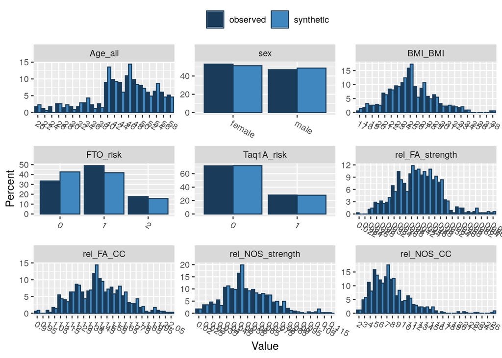

The distributions look very similar.

### Analysis of BMI and reward network connectivity

Now, we compare the output of the main analysis in the paper (`reward connectivity ~ age + sex + BMI`).

```r
R1 <- lm.synds(rel_NOS_CC ~ Age_all + factor(sex)  + BMI_BMI, data=syndata)
compare(R1, data_for_synth)
```

```
##
## Call used to fit models to the data:
## lm.synds(formula = rel_NOS_CC ~ Age_all + factor(sex) + BMI_BMI,
##     data = syndata)
##
## Differences between results based on synthetic and observed data:
##                 Std. coef diff p value CI overlap
## (Intercept)           1.399809   0.162  0.6428994
## Age_all               2.257448   0.024  0.4241098
## factor(sex)male       1.142710   0.253  0.7084869
## BMI_BMI              -3.118368   0.002  0.2044833
##
## Measures for one synthesis and 4 coefficients
## Mean confidence interval overlap:  0.4949949
## Mean absolute std. coef diff:  1.979584
## Lack-of-fit: 12.28112; p-value 0.015 for test that synthesis model is compatible
## with a chi-squared test with 4 degrees of freedom
##
## Confidence interval plot:
```

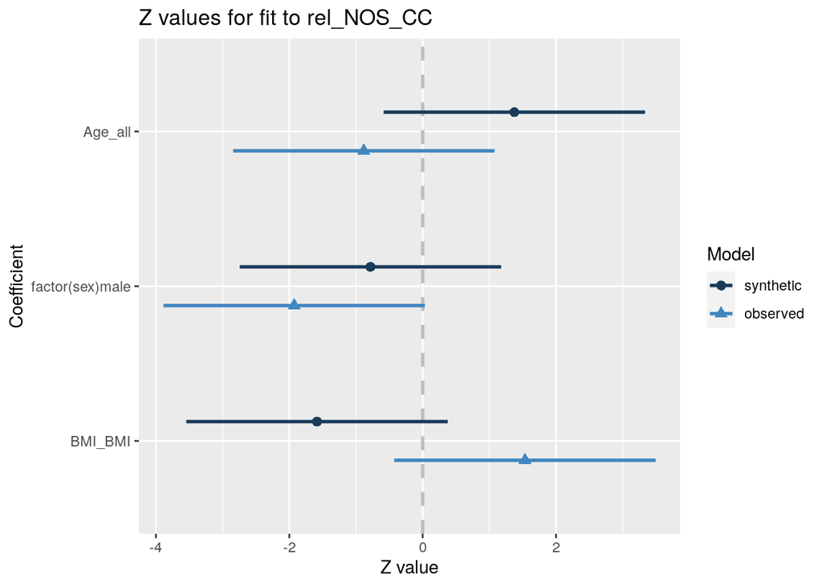

```r
R2 <- lm.synds(rel_NOS_strength ~ Age_all + factor(sex)  + BMI_BMI, data=syndata)
compare(R2, data_for_synth)
```

```
##
## Call used to fit models to the data:
## lm.synds(formula = rel_NOS_strength ~ Age_all + factor(sex) +
##     BMI_BMI, data = syndata)
##
## Differences between results based on synthetic and observed data:
##                 Std. coef diff p value CI overlap
## (Intercept)        -0.12846913   0.898  0.9672267
## Age_all             1.51533813   0.130  0.6134270
## factor(sex)male     0.08728331   0.930  0.9777334
## BMI_BMI            -0.84390994   0.399  0.7847129
##
## Measures for one synthesis and 4 coefficients
## Mean confidence interval overlap:  0.835775
## Mean absolute std. coef diff:  0.6437501
## Lack-of-fit: 2.898945; p-value 0.575 for test that synthesis model is compatible
## with a chi-squared test with 4 degrees of freedom
##
## Confidence interval plot:
```

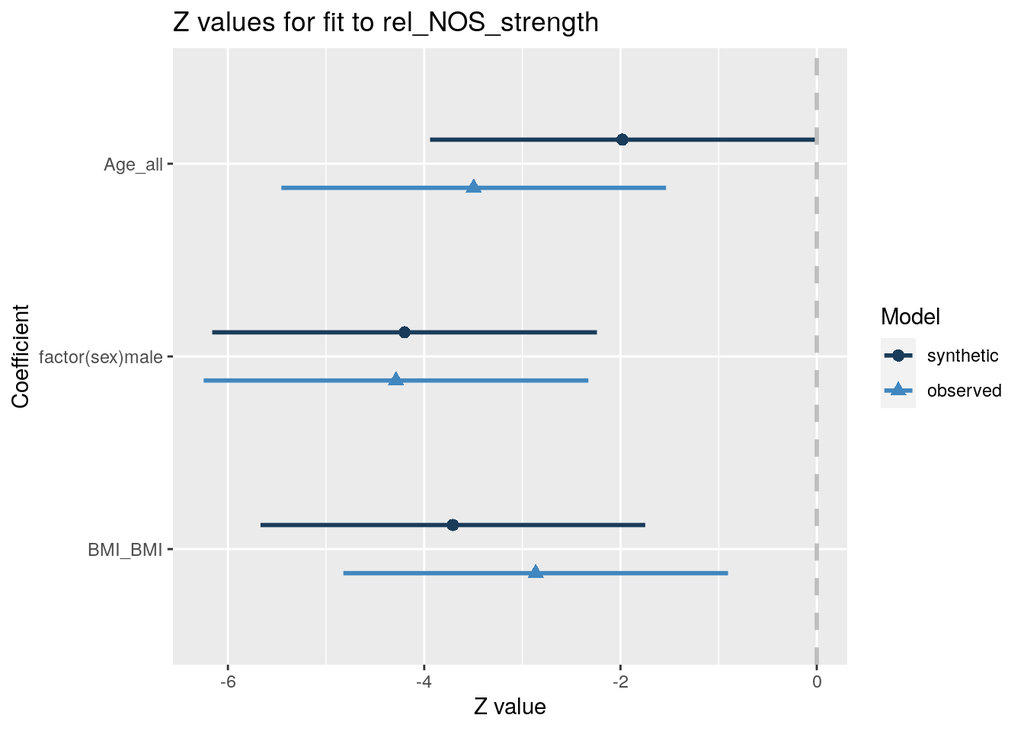

```r
R3 <- lm.synds(rel_FA_CC ~ Age_all + factor(sex)  + BMI_BMI, data=syndata)
compare(R3, data_for_synth)
```

```
##
## Call used to fit models to the data:
## lm.synds(formula = rel_FA_CC ~ Age_all + factor(sex) + BMI_BMI,
##     data = syndata)
##
## Differences between results based on synthetic and observed data:
##                 Std. coef diff p value CI overlap
## (Intercept)         1.03307142   0.302  0.7364565
## Age_all             0.28377781   0.777  0.9276064
## factor(sex)male    -0.04679098   0.963  0.9880633
## BMI_BMI            -1.09584556   0.273  0.7204424
##
## Measures for one synthesis and 4 coefficients
## Mean confidence interval overlap:  0.8431422
## Mean absolute std. coef diff:  0.6148714
## Lack-of-fit: 2.894325; p-value 0.576 for test that synthesis model is compatible
## with a chi-squared test with 4 degrees of freedom
##
## Confidence interval plot:
```

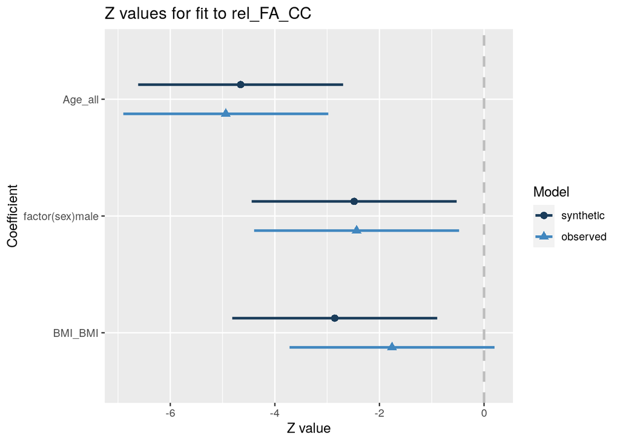

```r
R4 <- lm.synds(rel_FA_strength ~ Age_all + factor(sex)  + BMI_BMI, data=syndata)
compare(R4, data_for_synth)
```

```
##
## Call used to fit models to the data:
## lm.synds(formula = rel_FA_strength ~ Age_all + factor(sex) +
##     BMI_BMI, data = syndata)
##
## Differences between results based on synthetic and observed data:
##                 Std. coef diff p value CI overlap
## (Intercept)          0.8241199   0.410  0.7897615
## Age_all             -0.3525881   0.724  0.9100524
## factor(sex)male     -0.6498999   0.516  0.8342062
## BMI_BMI             -0.3745724   0.708  0.9044441
##
## Measures for one synthesis and 4 coefficients
## Mean confidence interval overlap:  0.859616
## Mean absolute std. coef diff:  0.5502951
## Lack-of-fit: 2.308249; p-value 0.679 for test that synthesis model is compatible
## with a chi-squared test with 4 degrees of freedom
##
## Confidence interval plot:
```

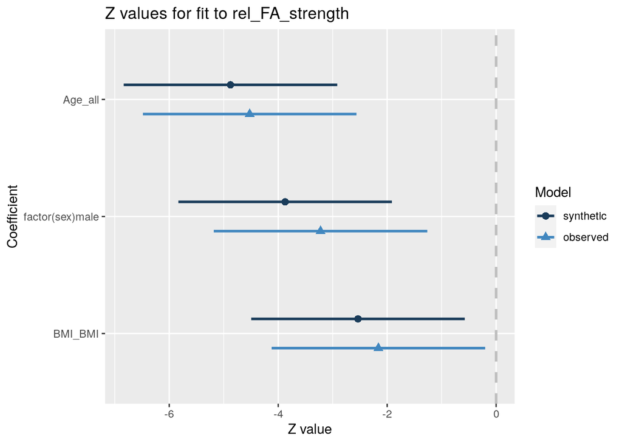

### Analysis of genetic variants, BMI and reward network connectivity

```r
R0 <- lm.synds(BMI_BMI ~ Age_all + factor(sex)  + FTO_risk + Taq1A_risk, data=syndata)
compare(R0, data_for_synth)
```

```
##
## Call used to fit models to the data:
## lm.synds(formula = BMI_BMI ~ Age_all + factor(sex) + FTO_risk +
##     Taq1A_risk, data = syndata)
##
## Differences between results based on synthetic and observed data:
##                 Std. coef diff p value CI overlap
## (Intercept)       -1.672778652   0.094  0.5732629
## Age_all            1.412216574   0.158  0.6397340
## factor(sex)male    1.411542671   0.158  0.6399060
## FTO_risk1          0.008475792   0.993  0.9978378
## FTO_risk2          0.118237013   0.906  0.9698369
## Taq1A_risk1       -0.364270386   0.716  0.9070722
##
## Measures for one synthesis and 6 coefficients
## Mean confidence interval overlap:  0.7879416
## Mean absolute std. coef diff:  0.8312535
## Lack-of-fit: 4.766394; p-value 0.574 for test that synthesis model is compatible
## with a chi-squared test with 6 degrees of freedom
##
## Confidence interval plot:
```

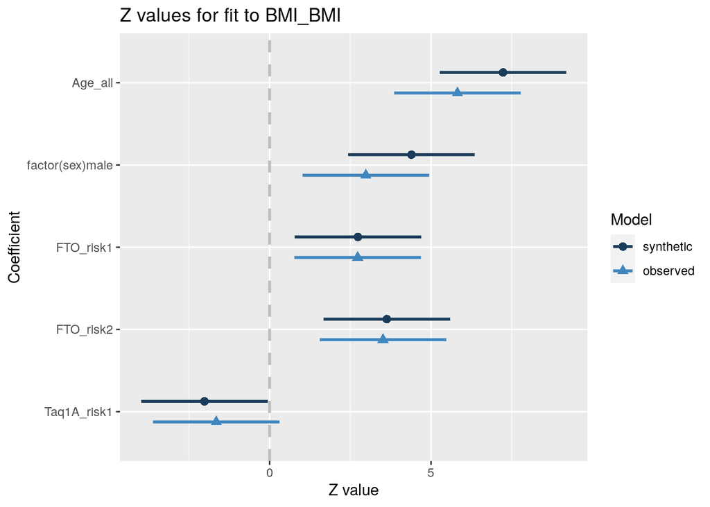

```r
R1 <- lm.synds(rel_NOS_strength ~ Age_all + factor(sex)  + FTO_risk + Taq1A_risk, data=syndata)
compare(R1, data_for_synth)
```

```
##
## Call used to fit models to the data:
## lm.synds(formula = rel_NOS_strength ~ Age_all + factor(sex) +
##     FTO_risk + Taq1A_risk, data = syndata)
##
## Differences between results based on synthetic and observed data:
##                 Std. coef diff p value CI overlap
## (Intercept)        -0.75065695   0.453  0.8085024
## Age_all             0.91103148   0.362  0.7675897
## factor(sex)male    -0.48253431   0.629  0.8769023
## FTO_risk1           0.61293516   0.540  0.8436361
## FTO_risk2           0.05098814   0.959  0.9869926
## Taq1A_risk1         0.56138917   0.575  0.8567858
##
## Measures for one synthesis and 6 coefficients
## Mean confidence interval overlap:  0.8567348
## Mean absolute std. coef diff:  0.5615892
## Lack-of-fit: 3.076069; p-value 0.799 for test that synthesis model is compatible
## with a chi-squared test with 6 degrees of freedom
##
## Confidence interval plot:
```

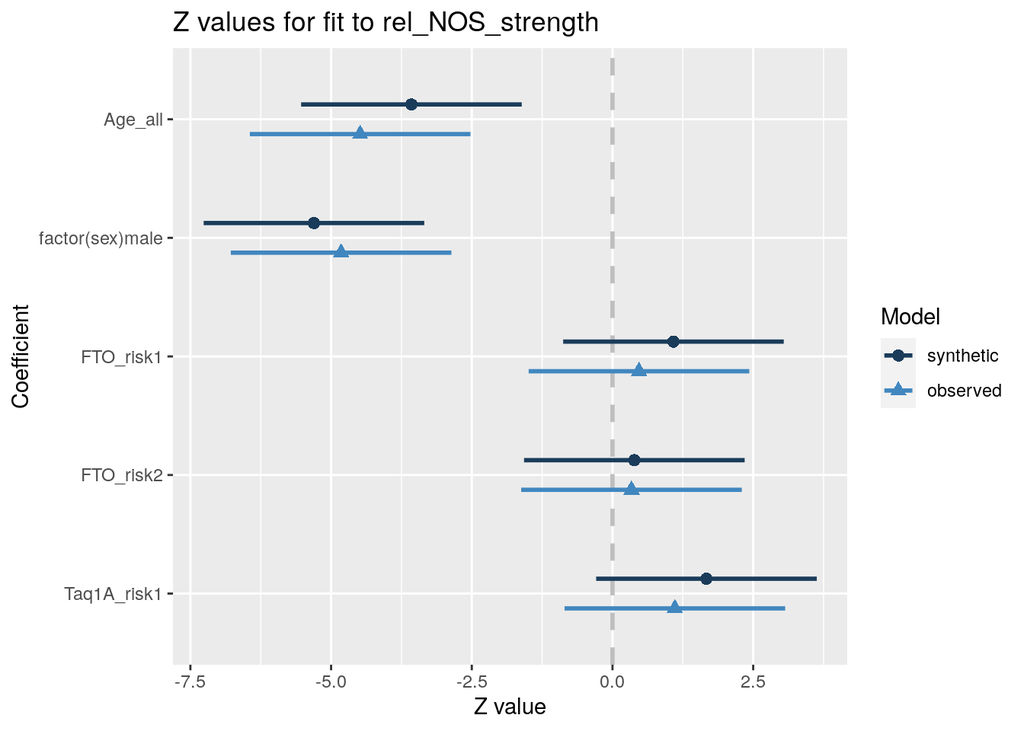

```r
R2 <- lm.synds(rel_FA_strength ~ Age_all + factor(sex)  + FTO_risk + Taq1A_risk, data=syndata)
compare(R2, data_for_synth)
```

```
##
## Call used to fit models to the data:
## lm.synds(formula = rel_FA_strength ~ Age_all + factor(sex) +
##     FTO_risk + Taq1A_risk, data = syndata)
##
## Differences between results based on synthetic and observed data:
##                 Std. coef diff p value CI overlap
## (Intercept)          0.7673617   0.443  0.8042409
## Age_all             -0.9121723   0.362  0.7672987
## factor(sex)male     -1.1042006   0.270  0.7183110
## FTO_risk1            1.0322652   0.302  0.7366622
## FTO_risk2            0.8684366   0.385  0.7784560
## Taq1A_risk1          2.4538150   0.014  0.3740153
##
## Measures for one synthesis and 6 coefficients
## Mean confidence interval overlap:  0.6964973
## Mean absolute std. coef diff:  1.189709
## Lack-of-fit: 11.54644; p-value 0.073 for test that synthesis model is compatible
## with a chi-squared test with 6 degrees of freedom
##
## Confidence interval plot:
```

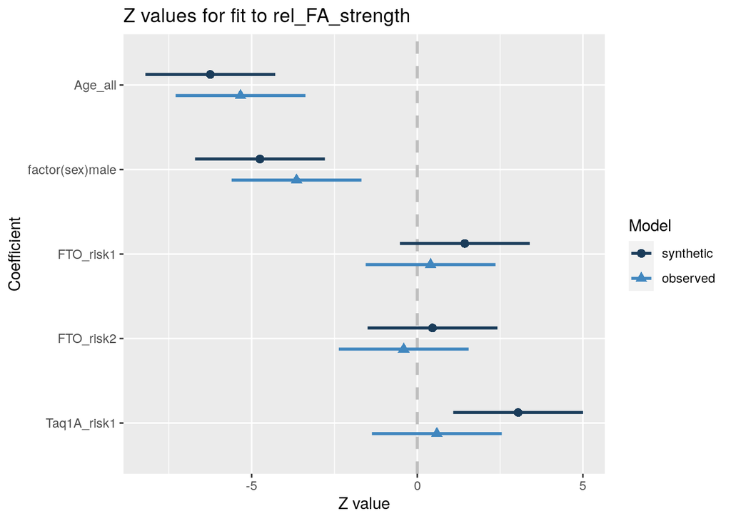

### Saving the synthetic data for further use

```r
write.csv(syndata$syn,"/data/p_life_results/2017_beyer_reward_connectivity/DTI/Paper_2019/BMI_rew_connectivity/synth_data.csv")
```